# LAB 03- Classification

Sachin Mohan Sujir

Including All Libraries

```r
require(ISLR)
require(MASS)
require(class)
```

1. Produce some numerical and graphical summaries of the Weekly data. Do there appear to be any patterns?

```r
data(Weekly)
summary(Weekly)
```

```
##       Year           Lag1               Lag2               Lag3
##  Min.   :1990   Min.   :-18.1950   Min.   :-18.1950   Min.   :-18.1950
##  1st Qu.:1995   1st Qu.: -1.1540   1st Qu.: -1.1540   1st Qu.: -1.1580
##  Median :2000   Median :  0.2410   Median :  0.2410   Median :  0.2410
##  Mean   :2000   Mean   :  0.1506   Mean   :  0.1511   Mean   :  0.1472
##  3rd Qu.:2005   3rd Qu.:  1.4050   3rd Qu.:  1.4090   3rd Qu.:  1.4090
##  Max.   :2010   Max.   : 12.0260   Max.   : 12.0260   Max.   : 12.0260
##       Lag4               Lag5              Volume
##  Min.   :-18.1950   Min.   :-18.1950   Min.   :0.08747
##  1st Qu.: -1.1580   1st Qu.: -1.1660   1st Qu.:0.33202
##  Median :  0.2380   Median :  0.2340   Median :1.00268
##  Mean   :  0.1458   Mean   :  0.1399   Mean   :1.57462
##  3rd Qu.:  1.4090   3rd Qu.:  1.4050   3rd Qu.:2.05373
##  Max.   : 12.0260   Max.   : 12.0260   Max.   :9.32821
##      Today          Direction
##  Min.   :-18.1950   Down:484
##  1st Qu.: -1.1540   Up  :605
##  Median :  0.2410
##  Mean   :  0.1499
##  3rd Qu.:  1.4050
##  Max.   : 12.0260
```

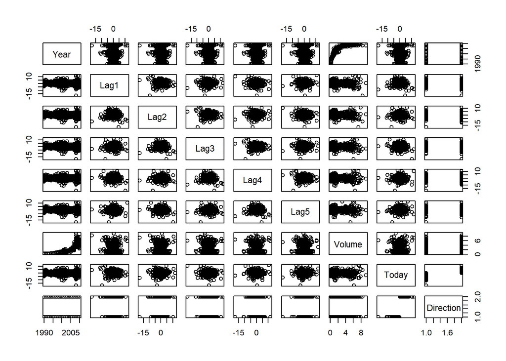

```r
pairs(Weekly)
```

```r
dim(Weekly)
```

```
## [1] 1089    9
```

The dataset contains 1089 records and 9 columns. The dataset contains 605 rows which have the direction up and 484 down.

(a)Produce some numerical and graphical summaries of the Weekly data. Do there appear to be any patterns?

#It seen from the scattert plotthat Volume and Year has logarithmic pattern

2. Use the full data set to perform a logistic regression with Direction as the response and the five lag variables plus Volume as predictors. Use the summary function to print the results. Do any of the predictors appear to be statistically significant? If so, which ones?

```r
attach(Weekly)
logModel = glm(Direction ~ Lag1 + Lag2 + Lag3 + Lag4 + Lag5 + Volume, family="binomial")
summary(logModel)
```

```
##
## Call:
## glm(formula = Direction ~ Lag1 + Lag2 + Lag3 + Lag4 + Lag5 +
##     Volume, family = "binomial")
##
## Deviance Residuals:
##     Min       1Q   Median       3Q      Max
## -1.6949  -1.2565   0.9913   1.0849   1.4579
##
## Coefficients:
##             Estimate Std. Error z value Pr(>|z|)
## (Intercept)  0.26686    0.08593   3.106   0.0019 **
## Lag1        -0.04127    0.02641  -1.563   0.1181
## Lag2         0.05844    0.02686   2.175   0.0296 *
## Lag3        -0.01606    0.02666  -0.602   0.5469
## Lag4        -0.02779    0.02646  -1.050   0.2937
## Lag5        -0.01447    0.02638  -0.549   0.5833
## Volume      -0.02274    0.03690  -0.616   0.5377
## ---
## Signif. codes:  0 '***' 0.001 '**' 0.01 '*' 0.05 '.' 0.1 ' ' 1
##
## (Dispersion parameter for binomial family taken to be 1)
##
##     Null deviance: 1496.2  on 1088  degrees of freedom
## Residual deviance: 1486.4  on 1082  degrees of freedom
## AIC: 1500.4
##
## Number of Fisher Scoring iterations: 4
```

With the summary on, it seems like the value for lag2 is statistically significant.Its estimate is 0.05844. All other predictors are insignificant.

The coefficients of these predictors suggests that as lag2 increases we have better probability of estimating the direction as Up. Negative coefficients predict the response as Down.

3. Compute the confusion matrix and overall fraction of correct predictions. Explain what the confusion matrix is telling you about the types of mistakes made by logistic regression.

```r
logModel.probs = predict(logModel, type="response")
logModel.preds = ifelse(logModel.probs>.5, "Up", "Down")
confusionMatrix = table(Weekly$Direction,logModel.preds)
confusionMatrix
```

```
##       logModel.preds
##        Down  Up
##   Down   54 430
##   Up     48 557
```

We can observe from the confusion matrix that the model will predict Up prediction better than the Down predictions.The number of True Positives suggests taht there is a trade off with respect to False Positives. We have obtained training accuracy of 56.1% by using this model.

From the confusion matrix we can see that for the prediction “Down” the model had an accuracy of **(54/(54+430))** i,e 11.1% acuurate but for the Up prediction the model has an accuracy of **557/(557+48)** i,e 92.06% accurate.

4. Now fit the logistic regression model using a training data period from 1990 to 2008, with Lag2 as the only predictor. Compute the confusion matrix and the overall fraction of correct predictions for the held out data(that is, the data from 2009 and 2010).

```r
trainingSet = Weekly[Year<2009,]
testSet = Weekly[Year>2008,]
logModel1 =glm(Direction ~ Lag2, data=trainingSet, family="binomial")
summary(logModel)
```

```
##
## Call:
## glm(formula = Direction ~ Lag1 + Lag2 + Lag3 + Lag4 + Lag5 +
##     Volume, family = "binomial")
##
## Deviance Residuals:
##     Min       1Q   Median       3Q      Max
## -1.6949  -1.2565   0.9913   1.0849   1.4579
##
## Coefficients:
##             Estimate Std. Error z value Pr(>|z|)
## (Intercept)  0.26686    0.08593   3.106   0.0019 **
## Lag1        -0.04127    0.02641  -1.563   0.1181
## Lag2         0.05844    0.02686   2.175   0.0296 *
## Lag3        -0.01606    0.02666  -0.602   0.5469
## Lag4        -0.02779    0.02646  -1.050   0.2937
## Lag5        -0.01447    0.02638  -0.549   0.5833
## Volume      -0.02274    0.03690  -0.616   0.5377
## ---
## Signif. codes:  0 '***' 0.001 '**' 0.01 '*' 0.05 '.' 0.1 ' ' 1
##
## (Dispersion parameter for binomial family taken to be 1)
##
##     Null deviance: 1496.2  on 1088  degrees of freedom
## Residual deviance: 1486.4  on 1082  degrees of freedom
## AIC: 1500.4
##
## Number of Fisher Scoring iterations: 4
```

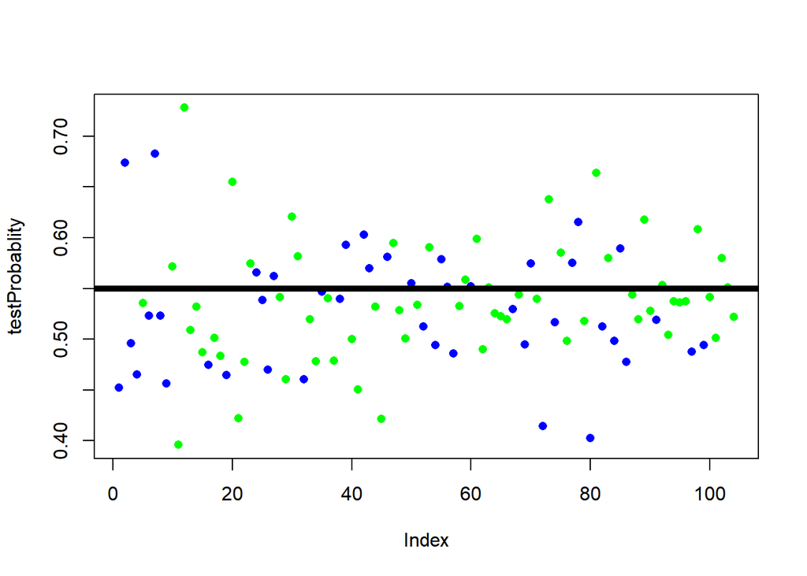

```r
testProbablity = predict(logModel, type="response", newdata = testSet)
testsDir = Direction[Year>2008]
plot(testProbablity, col= ifelse(Direction[Year>2008]=="Down", "Blue","Green"), pch=16)
abline(h = 0.55, lwd= 5)
```

```r
testPredictors = rep("Down", 104)
testPredictors[testProbablity>0.5] = "Up"
mean(testProbablity)
```

```
## [1] 0.5333256
```

```r
confMatrixLogReg = table(testsDir, testPredictors)
confMatrixLogReg
```

```
##         testPredictors
## testsDir Down Up
##     Down   17 26
##     Up     13 48
```

```r
correctPrediction= (confMatrixLogReg["Down", "Down"] + confMatrixLogReg["Up", "Up"])/sum(confMatrixLogReg)
correctPrediction
```

```
## [1] 0.625
```

```r
testerrorLogReg = ((1-correctPrediction)*100)
testerrorLogReg
```

```
## [1] 37.5
```

The Test error rate for logistic regression is 37.5% or 0.375

5. Repeat (d) using LDA.

```r
LDAmodel = lda(Direction~Lag2, data= trainingSet)
LDAmodel
```

```
## Call:
## lda(Direction ~ Lag2, data = trainingSet)
##
## Prior probabilities of groups:
##      Down        Up
## 0.4477157 0.5522843
##
## Group means:
##             Lag2
## Down -0.03568254
## Up    0.26036581
##
## Coefficients of linear discriminants:
##            LD1
## Lag2 0.4414162
```

```r
LDApredictions = predict(LDAmodel, newdata=testSet, type="response")
LDAclass = LDApredictions$class
confMatrixLDA = table(testSet$Direction,LDAclass)
confMatrixLDA
```

```
##       LDAclass
##        Down Up
##   Down    9 34
##   Up      5 56
```

```r
correctPrediction2= (confMatrixLDA["Down", "Down"] + confMatrixLDA["Up", "Up"])/sum(confMatrixLDA)
correctPrediction2
```

```
## [1] 0.625
```

```r
testerrorLDA = ((1-correctPrediction2)*100)
testerrorLDA
```

```
## [1] 37.5
```

Test error rate for LDA is same as logistic regression which is 37.5%

6. Repeat (d) using QDA.

```r
QDAmodel = qda(Direction~Lag2, data= trainingSet)
QDAmodel
```

```
## Call:
## qda(Direction ~ Lag2, data = trainingSet)
##
## Prior probabilities of groups:
##      Down        Up
## 0.4477157 0.5522843
##
## Group means:
##             Lag2
## Down -0.03568254
## Up    0.26036581
```

```r
QDApredictions = predict(QDAmodel, newdata=testSet, type="response")
QDAclass = QDApredictions$class
confMatrixQDA = table(testSet$Direction, QDAclass)
confMatrixQDA
```

```
##       QDAclass
##        Down Up
##   Down    0 43
##   Up      0 61
```

```r
correctPrediction3= (confMatrixQDA["Down", "Down"] + confMatrixQDA["Up", "Up"])/sum(confMatrixQDA)
correctPrediction3
```

```
## [1] 0.5865385
```

```r
testerrorQDA <- ((1-correctPrediction3)*100)
testerrorQDA
```

```
## [1] 41.34615
```

Test error rate for QDA is 41.34%

7. Repeat (d) using KNN with K = 1.

```r
set.seed(1)
training.X <- cbind(trainingSet$Lag2)
testing.X <- cbind(testSet$Lag2)
training.Y <- cbind(trainingSet$Direction)
KNNPredictions <- knn(training.X, testing.X, training.Y, k=1)
confMatrixKNN<-table(testSet$Direction, KNNPredictions)
confMatrixKNN
```

```
##       KNNPredictions
##         1  2
##   Down 21 22
##   Up   30 31
```

```r
correctPrediction4= (confMatrixKNN["Down", "1"] + confMatrixKNN["Up", "2"])/sum(confMatrixKNN)
correctPrediction4
```

```
## [1] 0.5
```

```r
testerrorKNN <- ((1-correctPrediction4)*100)
testerrorKNN
```

```
## [1] 50
```

Test error rate for KNN where K=1 is 50%

8. Which of these methods appears to provide the best results on this data? -> LDA and Logistic regression are the best model developed.

(h(i)) Experiment with different combinations of predictors, including possible transformations and interactions, for each of the methods. Report the variables, method, and associated confusion matrix that appears to provide the best results on the held out data. Note that you should also experiment with values for K in the KNN classifier.

Changing values of K in KNN. Let K=5.

```r
KNNPredictions5 <- knn(training.X, testing.X, training.Y, k=5)
confMatrixKNN5<-table(testSet$Direction, KNNPredictions5)
confMatrixKNN5
```

```
##       KNNPredictions5
##         1  2
##   Down 15 28
##   Up   20 41
```

```r
# correct predictions
correctPrediction5<- (confMatrixKNN5["Down", "1"] + confMatrixKNN5["Up", "2"])/sum(confMatrixKNN5)
correctPrediction5
```

```
## [1] 0.5384615
```

```r
# Test error rate

testerrorKNN5 <- ((1-correctPrediction5)*100)
testerrorKNN5
```

```
## [1] 46.15385
```

Lets try for K=50

```r
KNNPred50 <- knn(training.X, testing.X, training.Y, k=50)
confMatrixKNN50<-table(testSet$Direction, KNNPred50)
confMatrixKNN50
```

```
##       KNNPred50
##         1  2
##   Down 21 22
##   Up   20 41
```

```r
# correct predictions
correctPred50= (confMatrixKNN50["Down", "1"] + confMatrixKNN50["Up", "2"])/sum(confMatrixKNN50)
correctPred50
```

```
## [1] 0.5961538
```

```r
# Test error rate

testerrorKNN50 <- ((1-correctPred50)*100)
testerrorKNN50
```

```
## [1] 40.38462
```

Now checking LDA with all Lag predictor

```r
LDAmodel2 <- lda(Direction~Lag1 + Lag2 + Lag3 + Lag4 + Lag5, data= trainingSet)
LDAmodel2
```

```
## Call:
## lda(Direction ~ Lag1 + Lag2 + Lag3 + Lag4 + Lag5, data = trainingSet)
##
## Prior probabilities of groups:
##      Down        Up
## 0.4477157 0.5522843
##
## Group means:
##              Lag1        Lag2       Lag3       Lag4       Lag5
## Down  0.289444444 -0.03568254 0.17080045 0.15925624 0.21409297
## Up   -0.009213235  0.26036581 0.08404044 0.09220956 0.04548897
##
## Coefficients of linear discriminants:
##              LD1
## Lag1 -0.27604838
## Lag2  0.26309706
## Lag3 -0.04233861
## Lag4 -0.11994755
## Lag5 -0.15335694
```

```r
LDApredictions2 <- predict(LDAmodel2, newdata=testSet, type="response")
LDAclass2 <- LDApredictions2$class
confMatrixLDA2 <- table(testSet$Direction,LDAclass2)
confMatrixLDA2
```

```
##       LDAclass2
##        Down Up
##   Down    9 34
##   Up     13 48
```

```r
# correct predictions
correctPredictionLDA2<- (confMatrixLDA2["Down", "Down"] + confMatrixLDA2["Up", "Up"])/sum(confMatrixLDA2)
correctPredictionLDA2
```

```
## [1] 0.5480769
```

```r
# Test error rate

testerrorLDA2 <- ((1-correctPredictionLDA2)*100)
testerrorLDA2
```

```
## [1] 45.19231
```

We can see that including all lag as predictor made the model worst than previous

FOR QDA

```r
QDAmodel2 <- qda(Direction~Lag1 + Lag2 + Lag3 + Lag4 + Lag5, data= trainingSet)
QDAmodel2
```

```
## Call:
## qda(Direction ~ Lag1 + Lag2 + Lag3 + Lag4 + Lag5, data = trainingSet)
##
## Prior probabilities of groups:
##      Down        Up
## 0.4477157 0.5522843
##
## Group means:
##              Lag1        Lag2       Lag3       Lag4       Lag5
## Down  0.289444444 -0.03568254 0.17080045 0.15925624 0.21409297
## Up   -0.009213235  0.26036581 0.08404044 0.09220956 0.04548897
```

```r
QDApredictions2 <- predict(QDAmodel2, newdata=testSet, type="response")
QDAclass2 = QDApredictions$class
confMatrixQDA2 <- table(testSet$Direction, QDAclass2)
confMatrixQDA2
```

```
##       QDAclass2
##        Down Up
##   Down    0 43
##   Up      0 61
```

```r
# correct predictions
correctPredictionQDA2<- (confMatrixQDA2["Down", "Down"] + confMatrixQDA2["Up", "Up"])/sum(confMatrixQDA2)
correctPredictionQDA2
```

```
## [1] 0.5865385
```

```r
# Test error rate

testerrorQDA2 <- ((1-correctPrediction3)*100)
testerrorQDA2
```

```
## [1] 41.34615
```